# Cars Report

David Verbiest

2019-10-09

# Executive summary

In this equation **x stands for the squared speed**. This means that for every increase in squared speed of the car the breaking distance increase by 0.15. This means that **the breaking distance increases at a quadratic rate as the speed increases.** Or put in other words, the breaking distance becomes increasingly longer the faster you go.

The **model perfromed well** in terms of predicting test data, data never seen by the model before as estimated model **explained 99% of the variance** in the dependent variable. This can also be seen graphically as the **graphical representation** of the model **closely fits the test datapoints**.

# Analysis

## Exploration of the data

### The Data Set

Below you see the first *5 lins* of the used data set.

| name_of_car | speed_of_car | distance_of_car |
| --- | --- | --- |
| Ford | 4 | 2 |
| Jeep | 4 | 4 |
| Honda | 7 | 10 |
| KIA | 7 | 10 |
| Toyota | 8 | 14 |

### Summary Data Set

|  | name_of_car | speed_of_car | distance_of_car |
| --- | --- | --- | --- |
|  | Dodge : 3 | Min. : 4.0 | Min. : 2.00 |
|  | Honda : 3 | 1st Qu.:12.0 | 1st Qu.: 26.00 |
|  | Jeep : 3 | Median :15.0 | Median : 36.00 |
|  | KIA : 3 | Mean :15.4 | Mean : 42.98 |
|  | Acura : 2 | 3rd Qu.:19.0 | 3rd Qu.: 56.00 |
|  | Audi : 2 | Max. :25.0 | Max. :120.00 |
|  | (Other):34 | NA | NA |

### Boxplot: *Distance Of Car*

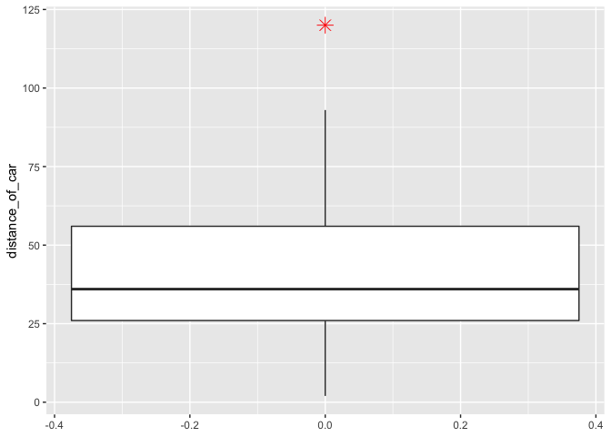

|  | x |
| --- | --- |
| 0% | 2 |
| 25% | 26 |
| 50% | 36 |
| 75% | 56 |
| 100% | 120 |

We can see that the there is **one outlier**. The following data point:

|  | name_of_car | speed_of_car | distance_of_car |
| --- | --- | --- | --- |
| 50 | Dodge | 25 | 120 |

## Preprocessing

In order not to bias the prediction we remove this data point from the training data.

We create a scatter plot between the variables speed of car and distance of car in order to spot any type of relationship between the two variables.

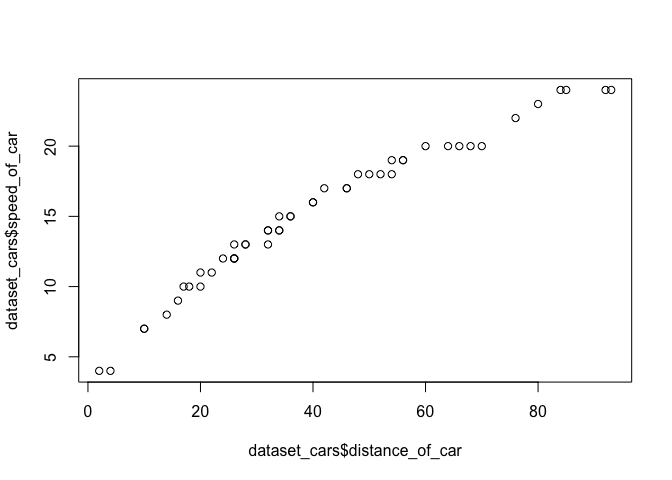

We see that there is pattern present, however the pattern is not linear. Distance a car needs to break increases for each marginal speed increase, hinting towards a quadratic relationship. This also makes sense given that velocity and acceleration (or in this case decelartion, which is can be seen as negative acceleration) are described by a second degree polynomials.

When we plot the the variable speed of car squared against the distance of car variable we see that relationship is linear.

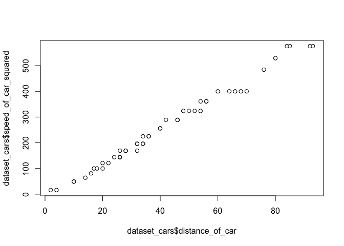

## Modeling

In order to estimate our model we use 70% of instances randomly selected from the data. We use the remaining 30% to test the resulting model. (We use the random seed:123)

```
##
## Call:
## lm(formula = distance_of_car ~ speed_of_car_squared, data = training_set)
##
## Residuals:
##    Min     1Q Median     3Q    Max
## -4.861 -1.218 -0.597  1.139  6.611
##
## Coefficients:
##                      Estimate Std. Error t value Pr(>|t|)
## (Intercept)          3.227165   0.810508   3.982 0.000369 ***
## speed_of_car_squared 0.150405   0.002718  55.337  < 2e-16 ***
## ---
## Signif. codes:  0 '***' 0.001 '**' 0.01 '*' 0.05 '.' 0.1 ' ' 1
##
## Residual standard error: 2.423 on 32 degrees of freedom
## Multiple R-squared:  0.9897, Adjusted R-squared:  0.9893
## F-statistic:  3062 on 1 and 32 DF,  p-value: < 2.2e-16
```

We can see that the p-value for our estimated parameters is less than 0.05 meaning that the estimates for our parameters significant with a confidence level 95%. The model also has a R squared of 98.9% on the training data, meaning that our model explains 98.9% of the variation in the data.

## Testing

We test our model on subset of test data that the model hasn’t seen before. The results are the following.

```
##
## Call:
## lm(formula = distance_of_car ~ speed_of_car_squared, data = test_set)
##
## Residuals:
##     Min      1Q  Median      3Q     Max
## -3.5119 -1.5764 -0.1701  1.3181  4.5681
##
## Coefficients:
##                      Estimate Std. Error t value Pr(>|t|)
## (Intercept)          2.159104   1.136916   1.899     0.08 .
## speed_of_car_squared 0.148182   0.003737  39.652    6e-15 ***
## ---
## Signif. codes:  0 '***' 0.001 '**' 0.01 '*' 0.05 '.' 0.1 ' ' 1
##
## Residual standard error: 2.289 on 13 degrees of freedom
## Multiple R-squared:  0.9918, Adjusted R-squared:  0.9912
## F-statistic:  1572 on 1 and 13 DF,  p-value: 6e-15
```

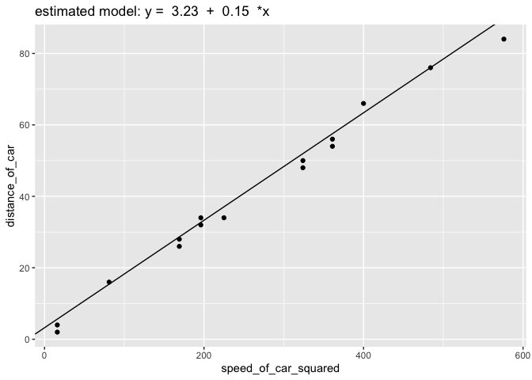

When we run our model on the test data we see that the R squared increases to 99.18% In other words our model can make strong predictions of the distance a car needs to break based on the squared speed of that car. We can also see this graphically as we see the the model closely alligns with the test data.

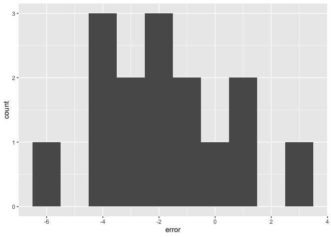